# Connectome Prediction Analysis

Raúl Rodríguez-Cruces

8 de septiembre de 2017

## Introduction

This protocol is based on Shen et al. 2017 for connectome prediction. However, it was originaly created for fMRI connectomes and some modifications have been performed in order to adecuate it for **structural connectivity matrices**.  
NOTE:  
> As in the reference paper, the predictive power of the model is assessed via correlation between predicted and observed scores across all subjects.  
> Note that this assumes normal or near-normal distributions for both vectors, and does not assess absolute accuracy of predictions (only relative accuracy within the sample).  
> It is recommended to explore *additional/alternative metrics for assessing predictive power*, such as prediction error sum of squares or prediction $r^2$.

## STEP 1: Inputs uploading

Here we upload the connectomes as a $MxMxN$ matrix and the cognitive variable as an $Nx1$ vector, where:  
- M = Number of nodes  
- N = Subjects  
- B = Behavior

The elements $(i,j)$ of each matrix represents the $N_{SIFT}$ weighted structural connection between two nodes for subject $k$.

## STEP 2: Trainning & Cross validation

Creates a training group each loop leaving one out. - **NOTE:** Should we do this only for the patients excluding controls??

## STEP 3: Relation of connectivity and behavior

This step was done by correlating each **edge** ($W_{ij}$) for all subjects ($EDGE_{ij}$) and the **behavioral measure**.  
We obtain two matrices whose edges represent the value of the $r$ and the $p-value$ for the correlation of the $EDGE_{ij}$ and the behavior.  
Alternatives for obtaining the correlation values are:  
- *Spearman* correlation  
- *Partial* correlations  
- *Robust regression* for correlating each edge with the behavioral measure

## STEP 4: Edge selection

Based on the significance of the p-values matrix with an *arbitrary threshold (0.01)*.  
The threshold is applied over the non corrected-p-values. As an **Alternative** a subselection of the nodes could be performed before this analysis in order to increase sensitivity and decreassed the multiple comparasion problem. This could be seen as an *hypothesis driven approach.*

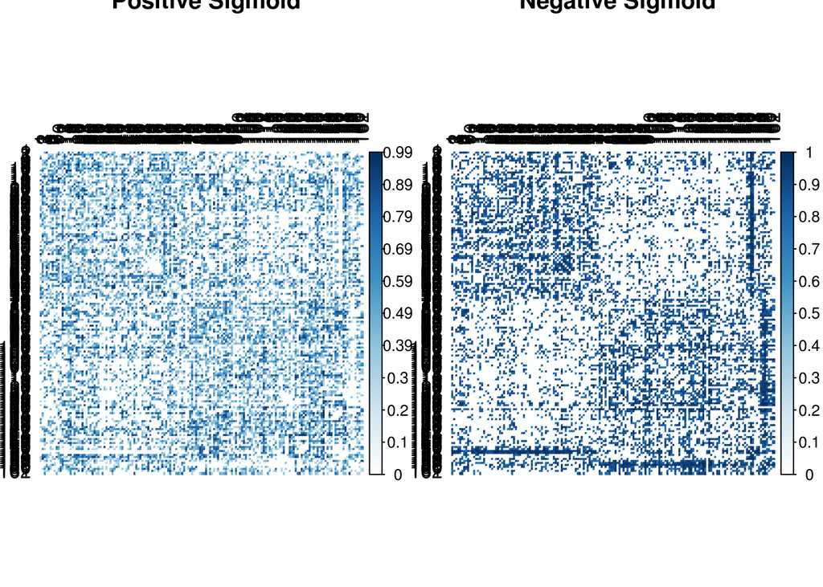

```r
    # Inverse of Student's T cumulative distribution function to obtain r threshold
    Th <- qt(thr/2,no_sub-1-2,lower.tail = TRUE)
    R <- sqrt(Th^2/(no_sub-1-2+Th^2))
    # Weighted mask using a sigmoidal function
    sigmf<-function(x,a,c){ y = 1/(1 + exp(-a*(x-c)))
      return(y) }
    # weight = 0.05, when correlation = R/3
    # weight = 0.88, when correlation = R
    neg.mask <-pos.mask <- r.mat
    pos.mask[pos.mask<0]<-0
    neg.mask[neg.mask>0]<-0

    pos.mask[pos.mask>0]<-sigmf(r.mat[r.mat>0],3/R,R/3)
    neg.mask[neg.mask<0]<-sigmf(r.mat[r.mat<0],-3/R,R/3)
    par(mfrow=c(1,2))
  corrplot(pos.mask,is.corr = F,tl.col="black",method="color",cl.pos = "r",title = "Positive Sigmoid")
  corrplot(neg.mask,is.corr = F,tl.col="black",method="color",cl.pos = "r",title="Negative Sigmoid")
```

# STEP 5: Single Subject Summay values ($SS\sum$)

For each subject in the training set, summarize the selected edges to a single value per subject for the positive edge set and the negative edge set separately

## STEP 8: Evaluation of the predictive model

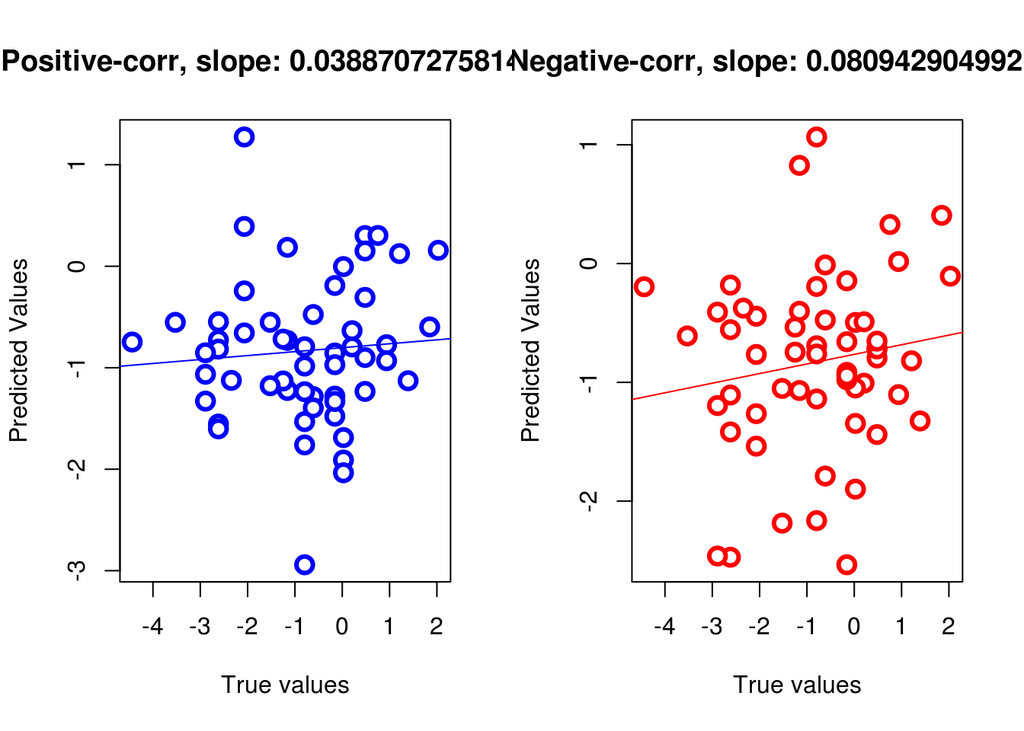

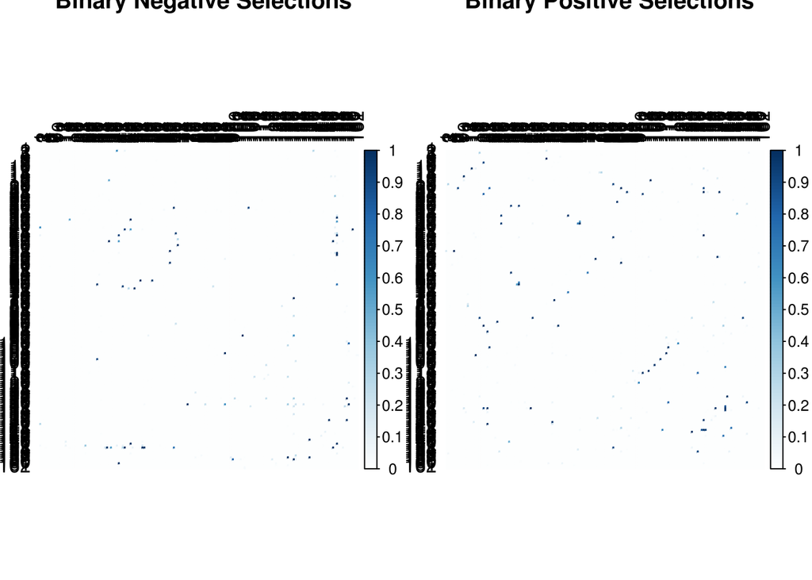